# Plotting

Jennifer Brazeal

9/5/19

Before we get started, let’s save data from an internal `datasets` package as a new object. This dataset is observations of CO2 uptake by plants originating from different locations (Quebec and Mississippi) and with different temperature treatments (chilled and not chilled) performed.

```r
CO2 = datasets::CO2
```

The head() function lets us take a quick look at the data - three columns of character vectors represented as ‘factors’, and two numeric columns

```r
head(CO2)
```

```
##   Plant   Type  Treatment conc uptake
## 1   Qn1 Quebec nonchilled   95   16.0
## 2   Qn1 Quebec nonchilled  175   30.4
## 3   Qn1 Quebec nonchilled  250   34.8
## 4   Qn1 Quebec nonchilled  350   37.2
## 5   Qn1 Quebec nonchilled  500   35.3
## 6   Qn1 Quebec nonchilled  675   39.2
```

While str() shows us more specific information about the structure of the data

```r
str(CO2)
```

```
## Classes 'nfnGroupedData', 'nfGroupedData', 'groupedData' and 'data.frame':   84 obs. of  5 variables:
##  $ Plant    : Ord.factor w/ 12 levels "Qn1"<"Qn2"<"Qn3"<..: 1 1 1 1 1 1 1 2 2 2 ...
##  $ Type     : Factor w/ 2 levels "Quebec","Mississippi": 1 1 1 1 1 1 1 1 1 1 ...
##  $ Treatment: Factor w/ 2 levels "nonchilled","chilled": 1 1 1 1 1 1 1 1 1 1 ...
##  $ conc     : num  95 175 250 350 500 675 1000 95 175 250 ...
##  $ uptake   : num  16 30.4 34.8 37.2 35.3 39.2 39.7 13.6 27.3 37.1 ...
##  - attr(*, "formula")=Class 'formula'  language uptake ~ conc | Plant
##   .. ..- attr(*, ".Environment")=<environment: R_EmptyEnv>
##  - attr(*, "outer")=Class 'formula'  language ~Treatment * Type
##   .. ..- attr(*, ".Environment")=<environment: R_EmptyEnv>
##  - attr(*, "labels")=List of 2
##   ..$ x: chr "Ambient carbon dioxide concentration"
##   ..$ y: chr "CO2 uptake rate"
##  - attr(*, "units")=List of 2
##   ..$ x: chr "(uL/L)"
##   ..$ y: chr "(umol/m^2 s)"
```

# Plot Types

## Plotting one continuous variable

### Histograms - groups the data into bins (default or custom defined) spanning the range of the data, and displays the frequency of each bin.

```r
?hist
```

```
## starting httpd help server ... done
```

Example:

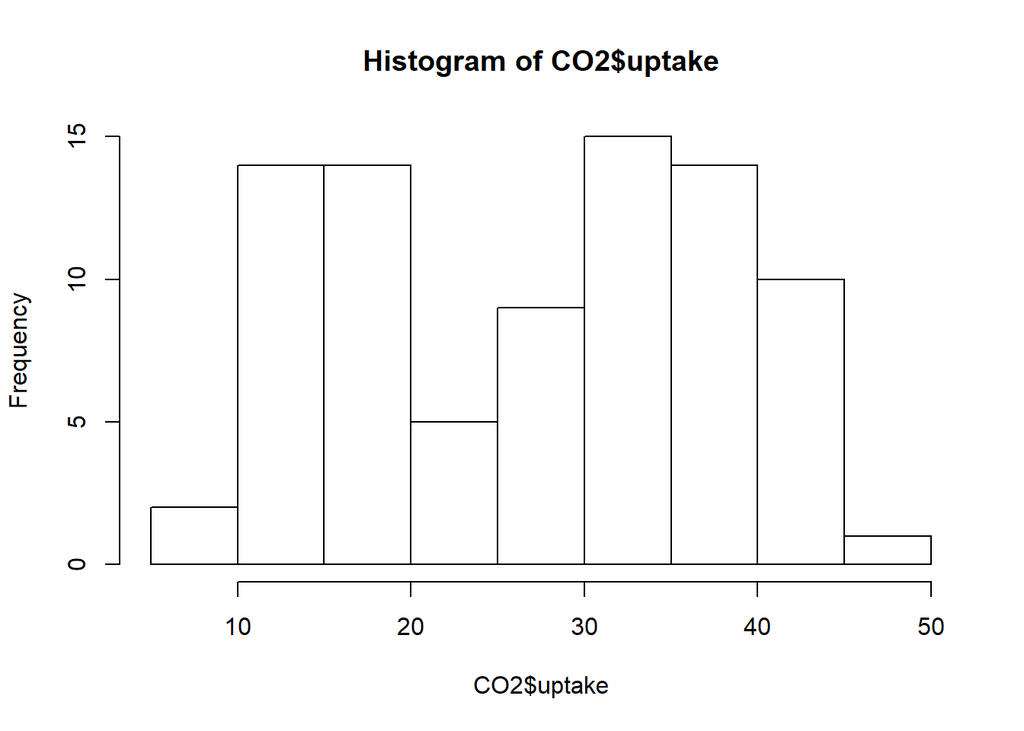

```r
hist(CO2$uptake)
```

### Density plots - Smooths out the data and displays density (analogous to continuous frequency) of data along the range of the data.

```r
?density # Combine with plot() to vizualize; i.e. plot(density(x))
```

Example:

```r
density(CO2$uptake)
```

```
##
## Call:
##  density.default(x = CO2$uptake)
##
## Data: CO2$uptake (84 obs.);  Bandwidth 'bw' = 4.012
##
##        x                y
##  Min.   :-4.337   Min.   :2.286e-05
##  1st Qu.:11.132   1st Qu.:2.863e-03
##  Median :26.600   Median :2.125e-02
##  Mean   :26.600   Mean   :1.615e-02
##  3rd Qu.:42.068   3rd Qu.:2.649e-02
##  Max.   :57.537   Max.   :3.095e-02
```

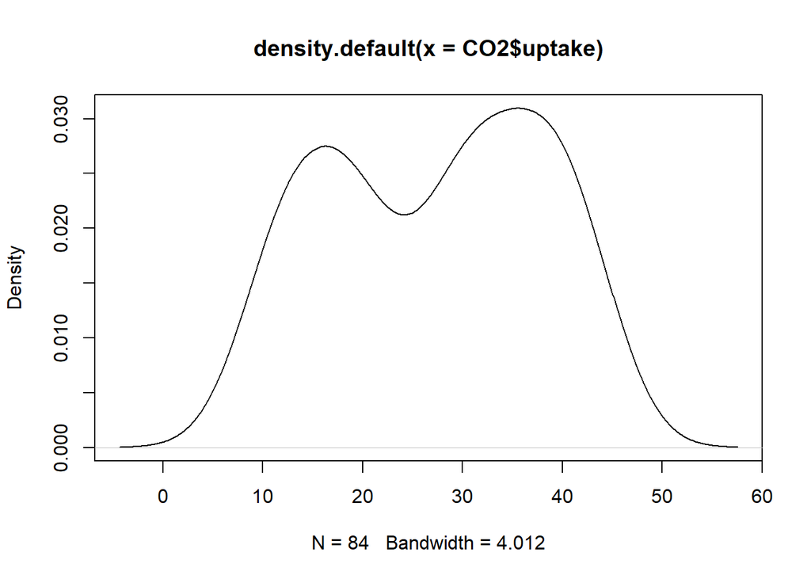

```r
plot(density(CO2$uptake))
```

### Dotcharts - Displays all point values along one dimension. In these plots, the X-axis shows the value you are plotting, while the Y-axis just separates out different data points

```r
?dotchart
```

Examples:  
Note, you can specify a grouping factor to divide the points and visually compare by group

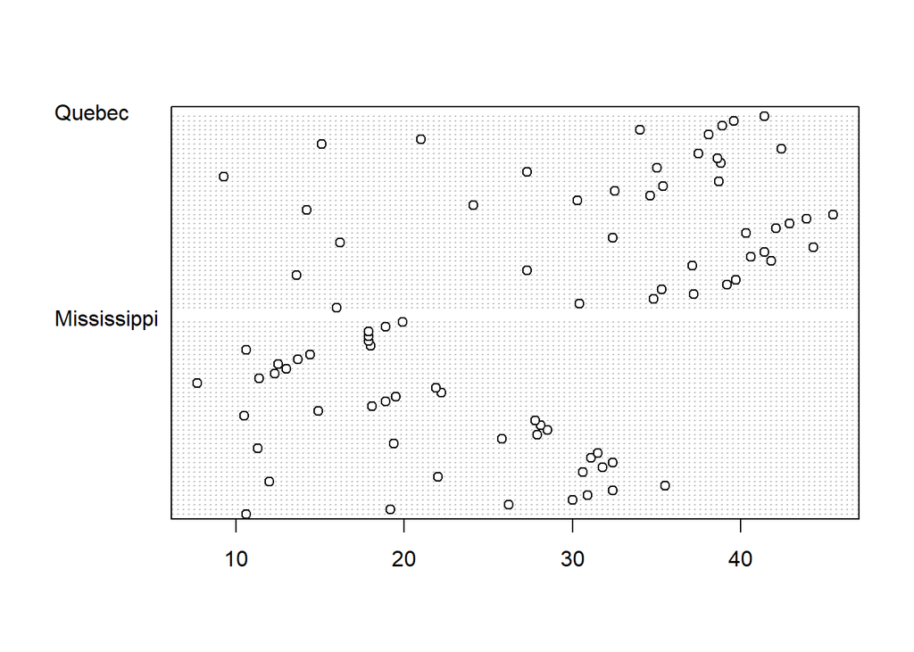

```r
dotchart(CO2$uptake, groups = CO2$Type) # separate out data by plant origin
```

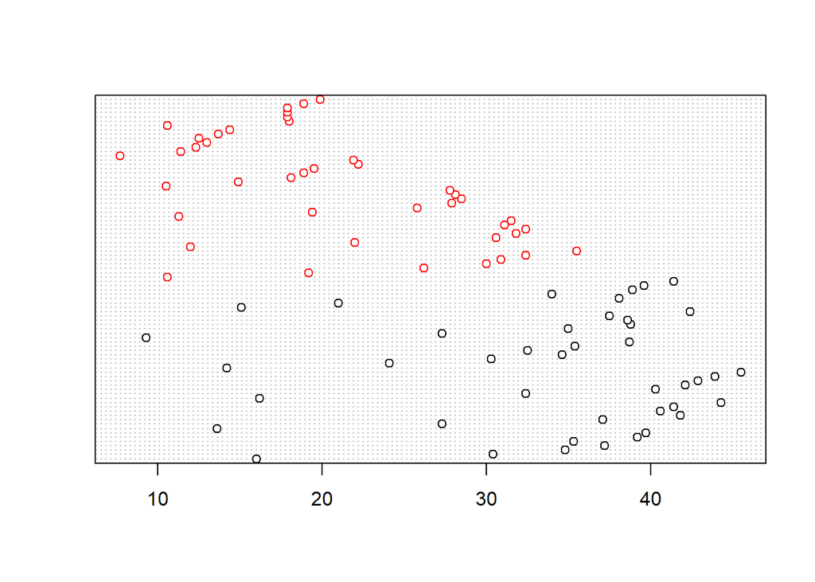

```r
dotchart(CO2$uptake, color = CO2$Type) # You can also just change the color to be different by plant origin
```

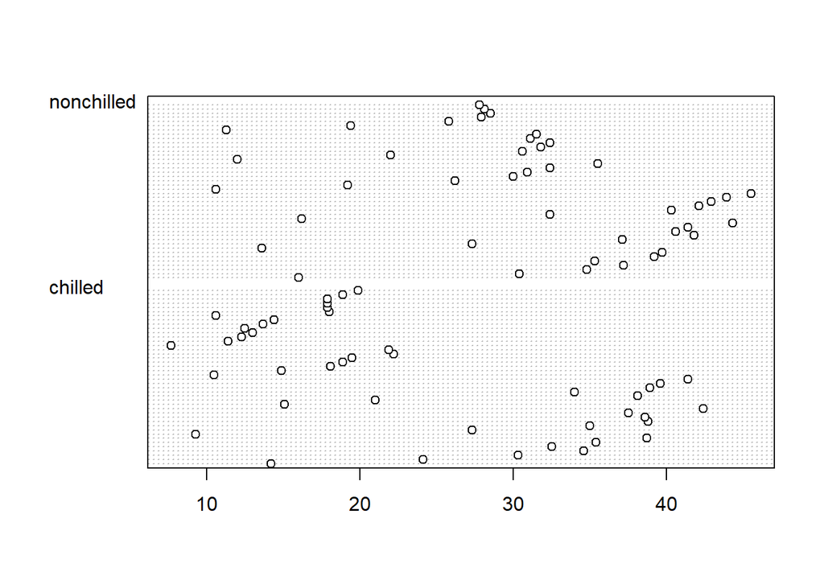

```r
dotchart(CO2$uptake, groups = CO2$Treatment) # And do the same for the different treatments (chilled vs. non-chilled)
```

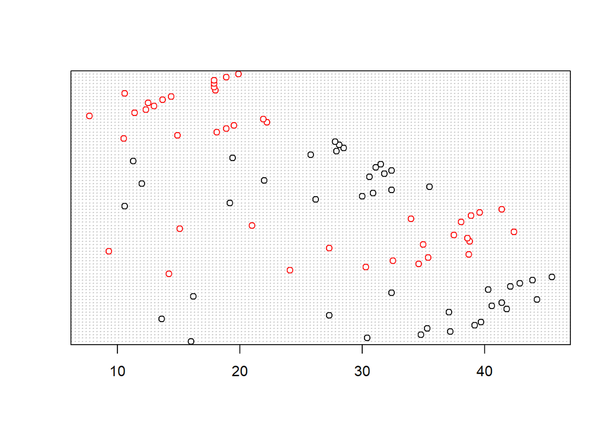

```r
dotchart(CO2$uptake, color = CO2$Treatment)
```

### Commentary: So far what have you noticed about CO2 uptake by plant country origin? What about by treatment?